# Week 2 Programming Assignment: Example

Danny Kaplan

June 9, 2015

Preliminary notes for this example answer:

- You should use a first-order heading `#⊔` for each exercise and a second-order heading `##⊔` for each exercise section. (The `⊔` refers to an empty space.)
- The section titles should be short but descriptive. If there is a label for the exercise section, e.g. (a), use it before your descriptive title.
- All your commands should be in “chunks”.
- All output should be displayed automatically through compiling Rmd -> HTML
- When output from a chunk is not needed, use `results = 'hide'`
- When loading a library, use `library( [package name], quietly = TRUE)`
- Don’t need a library unless you will need to use its features extensively. See item (a) for an example.
- Set interactive commands like `?Boston` in a chunk with `eval = FALSE`
- You should use `mosaic` commands rather than the “raw” commands used in ISL. There’s already a `library(mosaic)` in the template.
- When deciding on the length and detail of your answers, ignore the **Advanced Commentary** sections.

# Exercise 10 in ISL § 2.4

## (a) Load in the `Boston` data set

```r
data(Boston, package = "MASS")
```

```r
help(Boston, package = "MASS")
```

According to the documentation, there are 506 rows and 14 columns. The columns are various variables such as the average number of rooms per dwelling. The rows are … well they don’t explicitly say in the documentation. This is a major flaw in documentation. The rows (cases) seem to be towns near Boston, MA. For whatever reason, the towns are not identified by name.

## (b) Pairwise scatterplots

In *ISL* (p. 50), they suggest using `pairs()`.

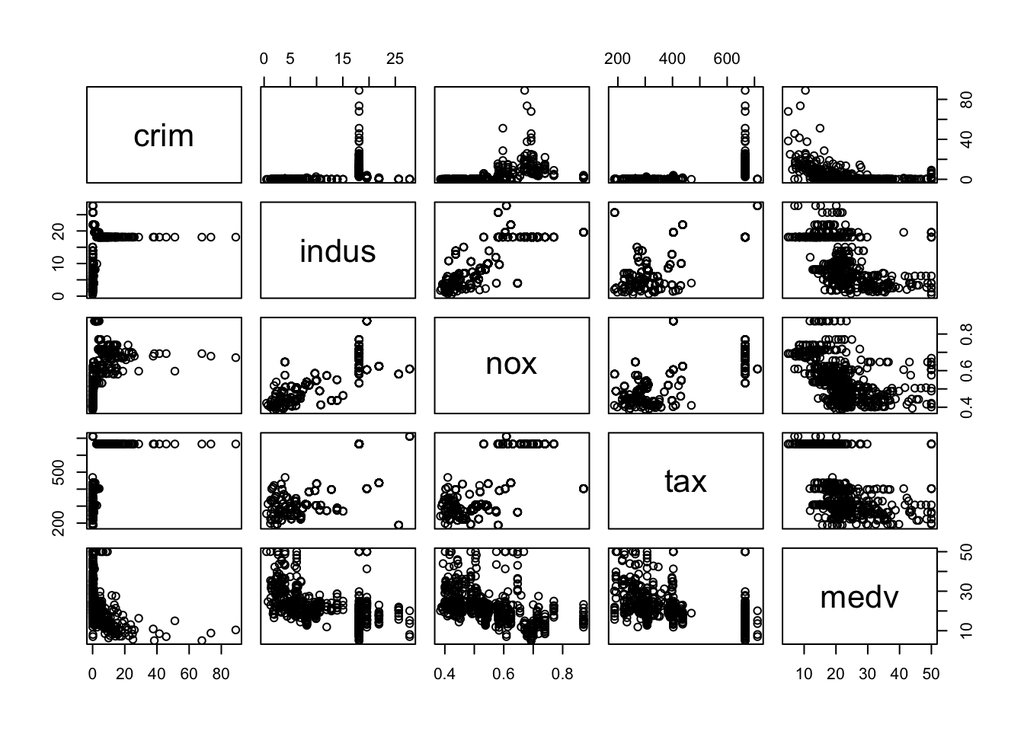

```r
pairs( ~ crim + indus + nox + tax + medv, data = Boston)
```

You could use `~ .` as a shorthand for “all the variables.” But there are too many here to make a sensible plot.

### Advanced Commentary

Each pair of variables is simply a scatter plot, as you can make with `xyplot()`.

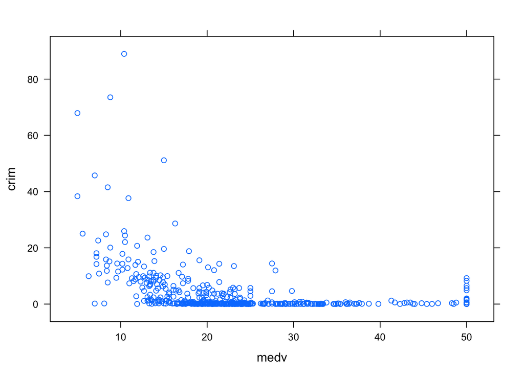

```r
xyplot(crim ~ medv, data=Boston)
```

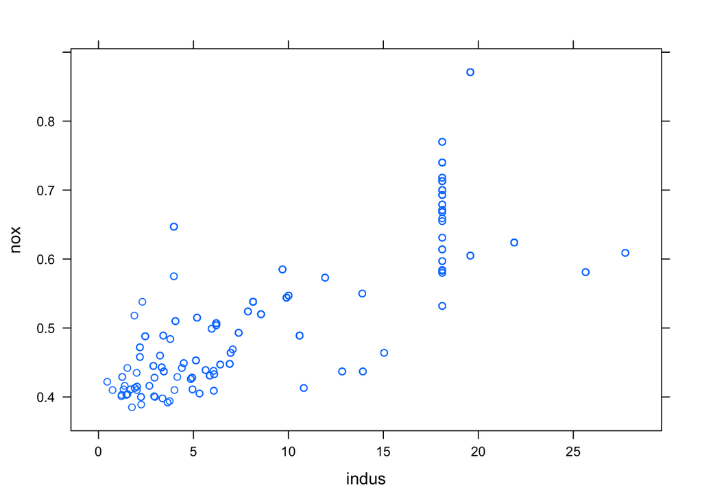

```r
xyplot(nox ~ indus, data=Boston)
```

Low median value of owner-occupied homes (`medv`) is associated with higher crime rates. Mid-level `medv` shows practically zero crime rate, while some high-level `medv` have non-zero rates.

Nitrogen oxides (`nox`) are associated with a higher proportion of non-retail business acres per town (`indus`).

## (c) Per capital crime rate

A simple way to look for associations between the predictor variables (a.k.a. *explanatory variables*) is the correlation coefficient:

```r
cor(crim ~ medv, data = Boston)
```

```
## [1] -0.3883046
```

```r
cor(crim ~ tax, data=Boston)
```

```
## [1] 0.5827643
```

```r
cor(crim ~ age, data=Boston)
```

```
## [1] 0.3527343
```

```r
# and so on
```

Higher crime rates are associated with lower median home value, higher taxes, and older housing stock.

### Advanced commentary

This “advanced commentary” is just to drop hints about what we will be doing later in the course. You are **not** expected to understand the details here. Think of the advanced commentary like a movie trailer.

#### More concise calculation

The correlations can be calculated for all the variables at once. Functions like `lapply()`, which iterate over all the items in a collection, are useful for this purpose. Here’s a pretty complicated statement that requires considerable explanation. For now, just think about what makes sense to you and what doesn’t

```r
Boston %>%
  lapply(FUN=function(x) cor(Boston$crim, x)) %>%
  unlist()
```

```
##        crim          zn       indus        chas         nox          rm         age         dis
##  1.00000000 -0.20046922  0.40658341 -0.05589158  0.42097171 -0.21924670  0.35273425 -0.37967009
##         rad         tax     ptratio       black       lstat        medv
##  0.62550515  0.58276431  0.28994558 -0.38506394  0.45562148 -0.38830461
```

#### Covariance matrix

There are many explanatory variables correlated with crime rate. But these explanatory variables are often correlated with each other. For interest, `nox` and `indus` are correlated, so if `nox` were (implausibly) the cause of crime, `indus` would have to be correlated as well.

To deal with this situation, it’s common to calculate the pairwise correlations between all the quantitative variables. This is called a covariance matrix:

```r
cor(Boston) %>%
  round(digits=2)
```

```
##          crim    zn indus  chas   nox    rm   age   dis   rad   tax ptratio black lstat  medv
## crim     1.00 -0.20  0.41 -0.06  0.42 -0.22  0.35 -0.38  0.63  0.58    0.29 -0.39  0.46 -0.39
## zn      -0.20  1.00 -0.53 -0.04 -0.52  0.31 -0.57  0.66 -0.31 -0.31   -0.39  0.18 -0.41  0.36
## indus    0.41 -0.53  1.00  0.06  0.76 -0.39  0.64 -0.71  0.60  0.72    0.38 -0.36  0.60 -0.48
## chas    -0.06 -0.04  0.06  1.00  0.09  0.09  0.09 -0.10 -0.01 -0.04   -0.12  0.05 -0.05  0.18
## nox      0.42 -0.52  0.76  0.09  1.00 -0.30  0.73 -0.77  0.61  0.67    0.19 -0.38  0.59 -0.43
## rm      -0.22  0.31 -0.39  0.09 -0.30  1.00 -0.24  0.21 -0.21 -0.29   -0.36  0.13 -0.61  0.70
## age      0.35 -0.57  0.64  0.09  0.73 -0.24  1.00 -0.75  0.46  0.51    0.26 -0.27  0.60 -0.38
## dis     -0.38  0.66 -0.71 -0.10 -0.77  0.21 -0.75  1.00 -0.49 -0.53   -0.23  0.29 -0.50  0.25
## rad      0.63 -0.31  0.60 -0.01  0.61 -0.21  0.46 -0.49  1.00  0.91    0.46 -0.44  0.49 -0.38
## tax      0.58 -0.31  0.72 -0.04  0.67 -0.29  0.51 -0.53  0.91  1.00    0.46 -0.44  0.54 -0.47
## ptratio  0.29 -0.39  0.38 -0.12  0.19 -0.36  0.26 -0.23  0.46  0.46    1.00 -0.18  0.37 -0.51
## black   -0.39  0.18 -0.36  0.05 -0.38  0.13 -0.27  0.29 -0.44 -0.44   -0.18  1.00 -0.37  0.33
## lstat    0.46 -0.41  0.60 -0.05  0.59 -0.61  0.60 -0.50  0.49  0.54    0.37 -0.37  1.00 -0.74
## medv    -0.39  0.36 -0.48  0.18 -0.43  0.70 -0.38  0.25 -0.38 -0.47   -0.51  0.33 -0.74  1.00
```

There are a variety of techniques for dealing with this mass of mutual associations.

## (d) Suburb-by-suburb analysis

This is a question about distributions.

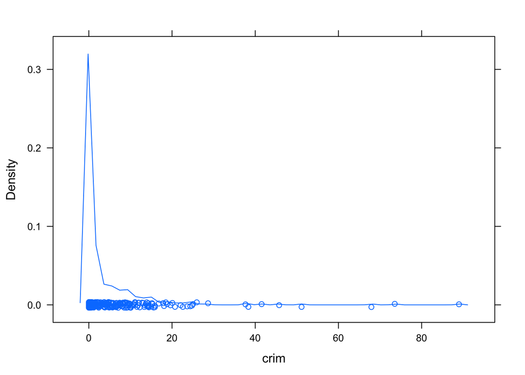

```r
densityplot( ~ crim, data = Boston)
```

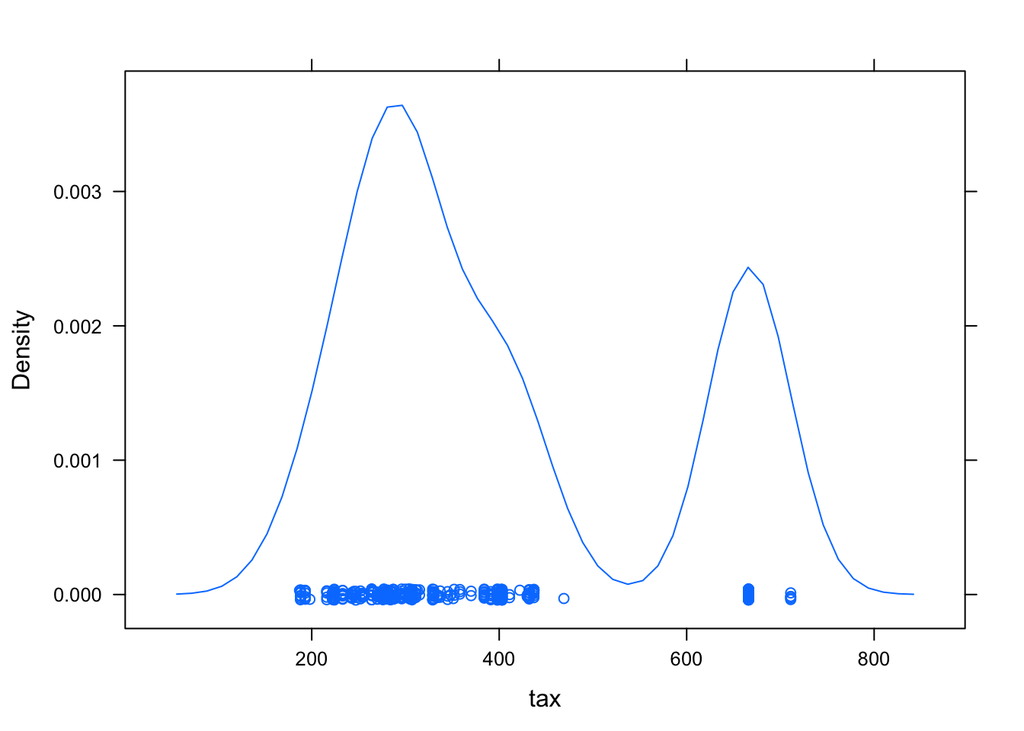

```r
densityplot( ~ tax, data = Boston)
```

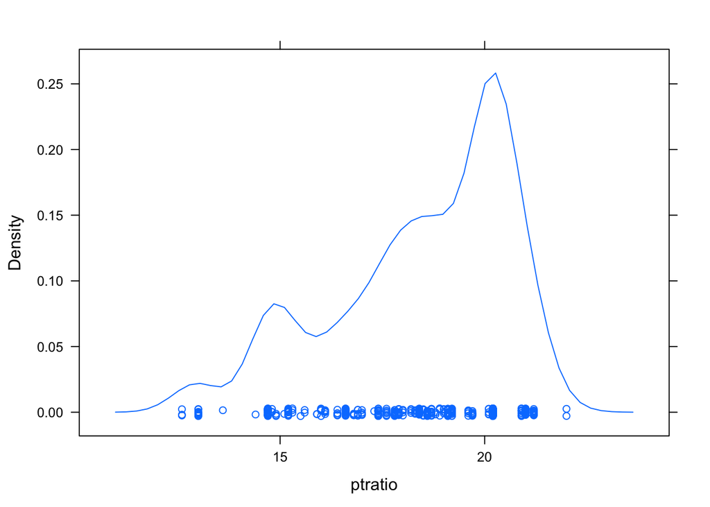

```r
densityplot( ~ ptratio, data = Boston)
```

```r
# and so on.
```

There are towns with exceptionally high tax rates and crime rates. And there are a few towns with low pupil-teacher ratios.

## (e) Charles river

Count how many towns abut the Charles River.

```r
sum(~chas, data=Boston)
```

```
## [1] 35
```

### Advanced Commentary

The above code is written using the `mosaic` package operators, which provide an easy way to summarise variables in a data set. In “base R”, this could be done in any of several ways:

```r
sum(Boston$chas)
```

```
## [1] 35
```

```r
with(Boston, sum(chas))
```

```
## [1] 35
```

Using `dplyr` data verbs, you could write:

```r
Boston %>%
  summarise(bound_the_charles = sum(chas))
```

```
##   bound_the_charles
## 1                35
```

## (f) Median pupil-teacher ratio

```r
median( ~ ptratio, data = Boston)
```

```
## [1] 19.05
```

### Advanced commentary

Or you could use the equivalent of any of the alternative forms given in (e).

## (g) Owner-occupied homes

Since the data set doesn’t identify the individual towns, the best we can do is to find the row number for the town with the lowest `medv`.

```r
low_medv <- subset(Boston, medv == min(medv))
low_medv
```

```
##        crim zn indus chas   nox    rm age    dis rad tax ptratio  black lstat medv
## 399 38.3518  0  18.1    0 0.693 5.453 100 1.4896  24 666    20.2 396.90 30.59    5
## 406 67.9208  0  18.1    0 0.693 5.683 100 1.4254  24 666    20.2 384.97 22.98    5
```

The style used in *ISL* (p. 50) might involve drawing a histogram and adding a vertical line to mark the location of the cases with lowest `medv`

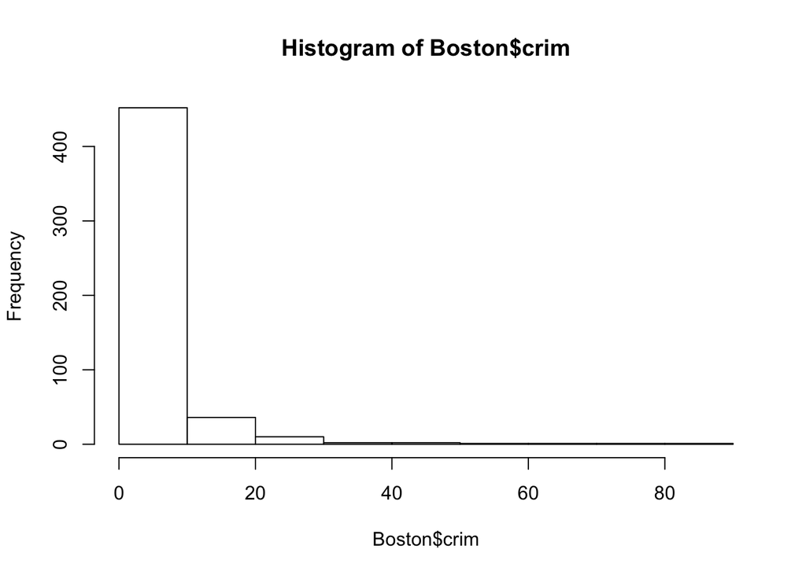

```r
hist(Boston$crim)
```

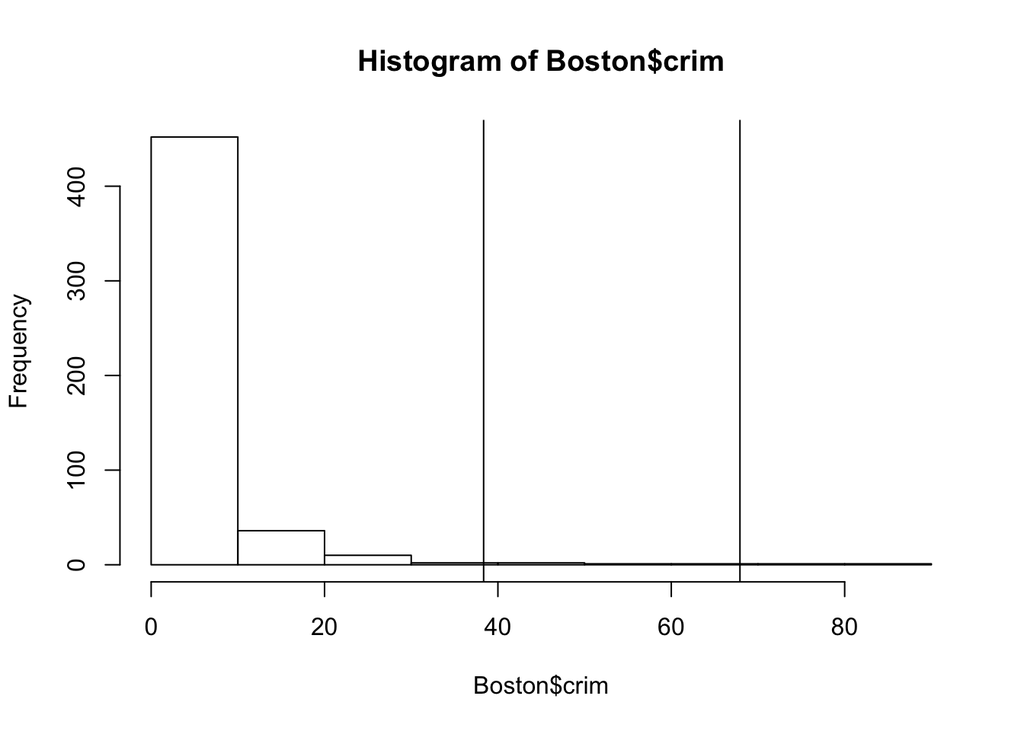

```r
abline(v = low_medv$crim)
```

## (h) Large dwellings

How many towns average more than seven rooms per dwelling? Eight rooms? Many different ways to compute this.

```r
with(Boston, table(rm > 7))
```

```
##
## FALSE  TRUE
##   442    64
```

```r
with(Boston, sum(rm > 7))
```

```
## [1] 64
```

```r
with(Boston, table(rm > 8))
```

```
##
## FALSE  TRUE
##   493    13
```

Let’s look at the towns with more than 8 rooms per dwelling. Again, there are many ways to do this.

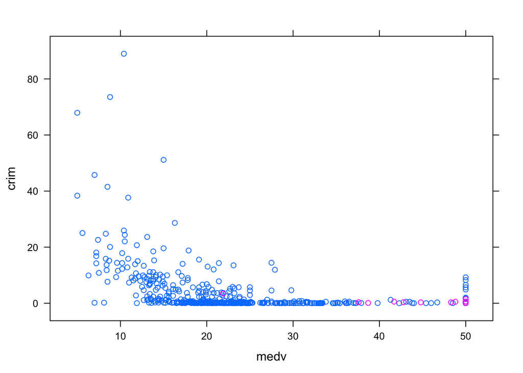

```r
xyplot(crim ~ medv, data=Boston, groups=Boston$rm > 8)
```

Mostly high value homes in low crime areas, but there is one exception.